# Time Series Homework: Chapter 5 Lesson 1

## Data

```r
## Women's Clothing Retail Sales

retail_ts <- rio::import("https://raw.githubusercontent.com/TBrost/BYUI-Timeseries-Drafts/refs/heads/master/data/retail_by_business_type.csv") |>
  filter(naics == 44812) |>
  mutate(month_seq = 1:n()) |>
  mutate(month = ym(month),
         year = year(month)) |>
  mutate(month_num = month(month)) |>
  filter(month >= ym("2004 Jan") & month <= ym("2006 Dec"))|>
  as_tsibble(index = month)
```

## Questions

### Question 1 - Key Definitions (10 points)

Answer the prompt to the learning outcome below. Include any mathematical expressions or illustrations that may accompany the definitions and ideas if available.

**Answer**

- **Define a linear time series model**

  A model which expresses the current value of a series as a linear combination of its own past values. It can be written in the following form: $x_t = \alpha_0 + \alpha_1u_{1,t}+...+\alpha_mu_{m,t}+z_t$.
- **Represent seasonal factors in a regression model using indicator variables**

  These are constant terms in the model which indicate whether a month is represented or not. They will equal 1 when $t$ is representing that month and 0 otherwise. For example if it is the month of January the model may look like $x_t = \alpha_1t + \beta_1 + z_t$ and February like so $x_t = \alpha_1t + \beta_2 + z_t$.
- **State how to remove a polynomial trend of order m**

  We can remove the polynomial trend by taking the $m$ difference.

### Question 2 - Linear model with additive seasonal indicator variables (40 points)

##### a) Use OLS to estimate a linear model with a linear trend, an intercept of 0 and additive seasonal indicator variables of the Women’s Clothing Retail Sales data set. Please report the estimates for the monthly seasonal indicator variables in a professionally formatted table. (See an example [HERE](https://byuistats.github.io/timeseries/chapter_5_lesson_1.html#tbl-chocolateParameterEstIndicator))

**Answer**

```r
retail_ts <- retail_ts |>
  mutate(stats_time = year + (month_num-1)/12,
         month_ = factor(month_num))




dat_lm <- retail_ts|>
  model(lm = TSLM(sales_millions ~ 0+stats_time + month_))



tidy(dat_lm)
```

```
# A tibble: 13 × 6
   .model term       estimate std.error statistic  p.value
   <chr>  <chr>         <dbl>     <dbl>     <dbl>    <dbl>
 1 lm     stats_time     161.      12.0      13.4 2.41e-12
 2 lm     month_1    -319679.   24053.      -13.3 2.80e-12
 3 lm     month_2    -319609.   24054.      -13.3 2.82e-12
 4 lm     month_3    -319009.   24055.      -13.3 2.93e-12
 5 lm     month_4    -318900.   24056.      -13.3 2.95e-12
 6 lm     month_5    -318937.   24057.      -13.3 2.95e-12
 7 lm     month_6    -319118.   24058.      -13.3 2.92e-12
 8 lm     month_7    -319380.   24059.      -13.3 2.87e-12
 9 lm     month_8    -319322.   24060.      -13.3 2.89e-12
10 lm     month_9    -319193.   24061.      -13.3 2.91e-12
11 lm     month_10   -319071.   24062.      -13.3 2.94e-12
12 lm     month_11   -318905.   24063.      -13.3 2.97e-12
13 lm     month_12   -317451.   24064.      -13.2 3.27e-12
```

##### b) Please interpret all of the estimated coefficients

**Answer**

The coefficients for the month indicators in a linear model with an intercept of 0 represent the expected number of sales in each month during the baseline time period, which is when the time variable equals zero. However, if the time series does not actually include data for that baseline period (e.g., year zero), these coefficients do not have a meaningful standalone interpretation. To make sense of them, it is more informative to consider how they compare to the average sales during the first observed year by accounting for the time trend. This helps contextualize the monthly differences within a realistic timeframe of the data.

##### c) Suppose that instead of estimating a model with an intercept of zero, you omit the month of July and let the model estimate an intercept. What would be the interpretation of the intercept estimate and the other coefficients?

**Answer**

The interpretation of the intercept would be the same as the coefficient for July above. However the interpretation of the other coefficients would be different and would be the difference between that particular month and July. This can be especially informative as a positive value means there are more sales in that month than July and a negative number would show there are less sales in that month than July.

##### d) Please make a five year forecast using the model you estimated in Part a. Use 95% confidence bands.

**Answer**

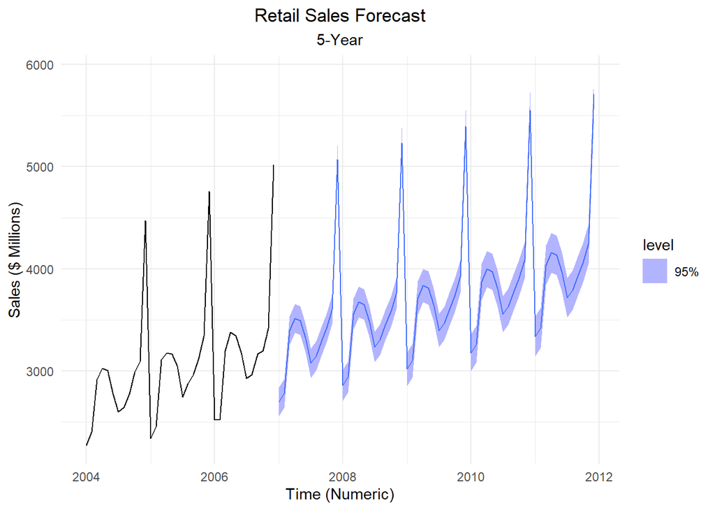

```r
num_years_to_forecast <- 5
df <- data.frame(
  month_ = factor(1:12),
  estimate = tidy(dat_lm) |> slice(2:13) |> pull(estimate)

)
num_years_to_forecast <- 5
num_months_to_forecast <- num_years_to_forecast * 12


last_time <- max(retail_ts$stats_time)
last_month <- retail_ts$month_num[which.max(retail_ts$stats_time)]


new_dat <- tibble(
  stats_time = seq(from = last_time + 1/12, by = 1/12, length.out = num_months_to_forecast),

    alpha = tidy(dat_lm) |> slice(1) |> pull(estimate),
  month_num = rep(1:12, times = num_years_to_forecast)
) |>
  mutate(month_ = factor(month_num, levels = levels(retail_ts$month_))) |>
  left_join(df, by = "month_")


retail_forecast <- dat_lm |>
  forecast(new_data = as_tsibble(new_dat, index = stats_time))


retail_forecast |>
  autoplot(retail_ts, level = 95) +
  labs(
    title = "Retail Sales Forecast",
    subtitle = "5-Year",
    y = "Sales ($ Millions)",
    x = "Time (Numeric)"
  ) +
  theme_minimal() +
  theme(
    plot.title = element_text(hjust = 0.5),
    plot.subtitle = element_text(hjust = 0.5)
  )
```

### Rubric

|  | **Mastery (10)** | **Incomplete (0)** |
| --- | --- | --- |
|  | The student correctly defined each of the terms and included mathematical expressions or illustration if available in the text or the Time Series Notebook | The student did not provide a correct definition for one or more of the terms. |
|  | **Mastery (10)** | **Incomplete (0)** |
|  | Students estimate the linear model using OLS and provide well-commented code. Results are presented clearly in a professionally formatted table. | Students struggle to estimate the linear model using OLS or provide poorly commented code. Results may be unclear or inaccurately presented in the table format. |
|  | **Mastery (5)** | **Incomplete (0)** |
|  | Students create clear plots with appropriate labeling and provide well-commented code. | Plots have insufficient clarity, labeling, or code comments, hindering the analysis of autocorrelation. |
|  | **Mastery (10)** | **Incomplete (0)** |
|  | Students fit residuals appropriately, selecting order based on correlogram and partial correlogram. They also include statistical evidence using R statistical tests of AR(p) model fit. They provide we… | Submissions struggle to fit residuals or select the order of autoregressive model using plots and statistical evidence |
|  | **Mastery (15)** | **Incomplete (0)** |
|  | Students accurately estimate the linear model using GLS using their results in part c. Results are presented clearly in a professionally formatted table that includes a comparison of the GLS and OLS p… | Submissions don’t implement the GLS algorithm correctly. Students don’t display the results professionally, or they don’t include a comparison to OLS results. |
|  | **Mastery (15)** | **Incomplete (0)** |
|  | Students provide clear analysis of autocorrelation bias and its forecasting implications. They point out the connection between standard errors and forecasting confidence bands. | Students may provide incomplete or inaccurate analysis of autocorrelation bias or its forecasting implications, lacking clarity or depth in discussion of its importance. |
|  | **Mastery (10)** | **Incomplete (0)** |
|  | Students accurately estimate the linear model using OLS, including seasonal indicator variables, and provide well-commented code. Results are presented clearly in a professionally formatted table. | Students struggle to estimate the linear model using OLS or provide poorly commented code. Results may be unclear or inaccurately presented in the table format. |
|  | **Mastery (10)** | **Incomplete (0)** |
|  | Students provide a correct interpretation of the coefficient for January (including the correct units). and relate to the effect on the Women’s Clothing Retail Sales. | Interpretation of the coefficient for January is incomplete, inaccurate, or unclear, lacking a direct connection to its effect on the Women’s Clothing Retail Sales. |
|  | **Mastery (10)** | **Incomplete (0)** |
|  | Students provide a clear interpretation of the intercept estimate in the context of the Women’s Clothing Retail Sales data, considering how it relates to the additive seasonal indicator variables | Interpretation of the intercept estimate may be incomplete, inaccurate, or unclear. It doesn’t make clear the perfect colinearity problem and the correct interpretation of the dropped variable. |
|  | **Mastery (10)** | **Incomplete (0)** |
|  | Students accurately make the five-year forecast using the estimated model, including 95% confidence bands in their plot. | Students encounter difficulties in making the five-year forecast or don’t include the forecast plot. Code may be poorly commented or the inclusion of confidence bands may be omitted. |
| **Total Points** | **105** |  |